# 备砖： 用R进行数据管理2

2018年

## 内容提纲

- 数据读入 Data import
  - 导入CSV数据
  - haven导入SPSS、stata数据
  - foreign包导入SPSS、stata数据
  - 读入数据库数据
- 数据整理 Tidy data
  - 理想的数据结构
  - 宽数据变长数据:gather
  - 长数据变宽数据:spread
  - 数据的合并:merge & join

## 数据读入

## R读入CSV等文本数据

使用tidyverse中的readr包：

```r
library(tidyverse)
library(readr)
dataset <- read_csv(文件路径和文件名)
```

- read_csv() 读入csv文件,
- read_csv2() 读入封号分割文件
- read_tsv() 读入制表符分割文件
- read_delim() 读入各种固定分隔符文件.
- read_fwf() 读入固定宽度文件；用 fwf_widths() or fwf_positions()设定栏位
- read_table() 读入空格分割的固定宽度文件
- read_log() 读入Apache风格的log文件。更复可参考`webreadr` 。

## R读入固定分隔文件

使用菜单：

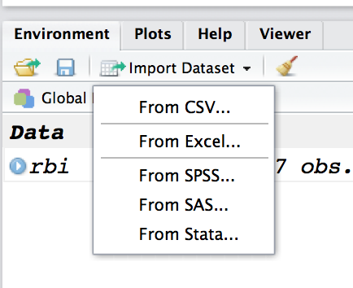

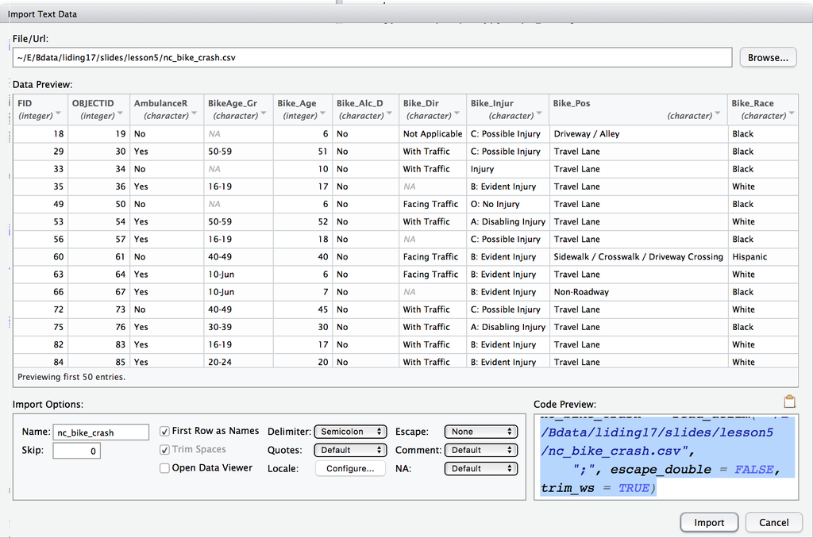

## R读入固定分割文件

Rstudio推荐的是用readr包，自动变为tbl文件。 读入一个北卡罗来纳州的自行车交通事故相关的数据。

```r
library(readr)
bike <- read_delim("../data/nc_bike_crash.csv", ";",
    escape_double = FALSE, trim_ws = TRUE)
```

```r
class(bike)
```

```
## [1] "tbl_df"     "tbl"        "data.frame"
```

下载数据 https://stat.duke.edu/~mc301/data/nc_bike_crash.csv

更多信息 https://stat.duke.edu/~mc301/data/nc_bike_crash.html.

[原始网站](https://opendurham.nc.gov/explore/dataset/north_carolina_bicycle_crash_data_heatmap_/table/)

## R读入固定分割文件

使用utils包中的read.table和read.csv命令，进一步变为tbl文件

```r
bike <- read.csv("../data/nc_bike_crash.csv",
                 sep = ";",
                 stringsAsFactors = FALSE) %>%
       tbl_df()
class(bike)
```

## 查看数据及其属性

命令格式：

```r
View(data)
class(data)
str(data)
head(data)
dim(data)
names(data)
```

例如：

```r
dim(bike)
```

```
## [1] 5716   54
```

```r
str(bike)
```

```
## Classes 'tbl_df', 'tbl' and 'data.frame':    5716 obs. of  54 variables:
##  $ FID       : int  18 29 33 35 49 53 56 60 63 66 ...
##  $ OBJECTID  : int  19 30 34 36 50 54 57 61 64 67 ...
##  $ AmbulanceR: chr  "No" "Yes" "No" "Yes" ...
##  $ BikeAge_Gr: chr  NA "50-59" NA "16-19" ...
##  $ Bike_Age  : int  6 51 10 17 6 52 18 40 6 7 ...
##  $ Bike_Alc_D: chr  "No" "No" "No" "No" ...
##  $ Bike_Dir  : chr  "Not Applicable" "With Traffic" "With Traffic" NA ...
##  $ Bike_Injur: chr  "C: Possible Injury" "C: Possible Injury" "Injury" "B: Evident Injury" ...
##  $ Bike_Pos  : chr  "Driveway / Alley" "Travel Lane" "Travel Lane" "Travel Lane" ...
##  $ Bike_Race : chr  "Black" "Black" "Black" "White" ...
##  $ Bike_Sex  : chr  "Female" "Male" "Male" "Male" ...
##  $ City      : chr  "Durham" "Greenville" "Farmville" "Charlotte" ...
##  $ County    : chr  "Durham" "Pitt" "Pitt" "Mecklenburg" ...
##  $ CrashAlcoh: chr  "No" "No" "No" "No" ...
##  $ CrashDay  : chr  "01-01-06" "01-01-02" "01-01-07" "01-01-05" ...
##  $ Crash_Date: Date, format: "2007-01-06" "2007-01-09" ...
##  $ Crash_Grp : chr  "Bicyclist Failed to Yield - Midblock" "Crossing Paths - Other Circumstances" "Bicyclist Failed to Yield - Sign-Controlled Intersection" "Loss of Control / Turning Error" ...
##  $ Crash_Hour: int  13 23 16 19 12 20 19 14 16 0 ...
##  $ Crash_Loc : chr  "Non-Intersection" "Intersection-Related" "Intersection" "Intersection" ...
##  $ Crash_Mont: chr  NA NA NA NA ...
##  $ Crash_Time: POSIXct, format: "0001-01-01 13:17:58" "0001-01-01 23:08:58" ...
##  $ Crash_Type: chr  "Bicyclist Ride Out - Residential Driveway" "Crossing Paths - Intersection - Other /" "Bicyclist Ride Through - Sign-Controlled Intersection" "Motorist Lost Control - Other /" ...
##  $ Crash_Ty_1: int  353311 211180 111144 119139 112114 311231 119144 132180 112142 460910 ...
##  $ Crash_Year: int  2007 2007 2007 2007 2007 2007 2007 2007 2007 2007 ...
##  $ Crsh_Sevri: chr  "C: Possible Injury" "C: Possible Injury" "O: No Injury" "B: Evident Injury" ...
##  $ Developmen: chr  "Residential" "Commercial" "Residential" "Residential" ...
##  $ DrvrAge_Gr: chr  "60-69" "30-39" "50-59" "30-39" ...
##  $ Drvr_Age  : int  66 34 52 33 NA 20 40 NA 17 51 ...
##  $ Drvr_Alc_D: chr  "No" "No" "No" "No" ...
##  $ Drvr_EstSp: chr  "11-15 mph" "0-5 mph" "21-25 mph" "46-50 mph" ...
##  $ Drvr_Injur: chr  "O: No Injury" "O: No Injury" "O: No Injury" "O: No Injury" ...
##  $ Drvr_Race : chr  "Black" "Black" "White" "White" ...
##  $ Drvr_Sex  : chr  "Male" "Male" "Female" "Female" ...
##  $ Drvr_VehTy: chr  "Pickup" "Passenger Car" "Passenger Car" "Sport Utility" ...
##  $ ExcsSpdInd: chr  "No" "No" "No" "No" ...
##  $ Hit_Run   : chr  "No" "No" "No" "No" ...
##  $ Light_Cond: chr  "Daylight" "Dark - Lighted Roadway" "Daylight" "Dark - Roadway Not Lighted" ...
##  $ Locality  : chr  "Mixed (30% To 70% Developed)" "Urban (>70% Developed)" "Mixed (30% To 70% Developed)" "Urban (>70% Developed)" ...
##  $ Num_Lanes : chr  "2 lanes" "5 lanes" "2 lanes" "4 lanes" ...
```

[output cut: 115 more lines]

[output not shown]

## 读入SPSS、stata或SAS数据

Rstudio推荐使用**haven**包读入数据

```r
library(haven)
data1 <- read_sav("路径+文件名.sav")
data2 <- read_stata("路径+文件名.dta",encoding ="GB2312")
data3 <- read_sas("路径+文件名.sas7bdat")
```

**haven**包读入数据后，变量和取值标签变为变量的属性。

Stata14之前的数据无Encoding信息,中文数据可能是GB2312编码。

Stata14版本支持unicode编码。haven默认可以读入。

## haven读入stata数据:CGSS

预览为乱码时，可尝试设定encoding=“GB2312”或encoding=“gbk”。无乱码encoding为默认的utf-8即可。

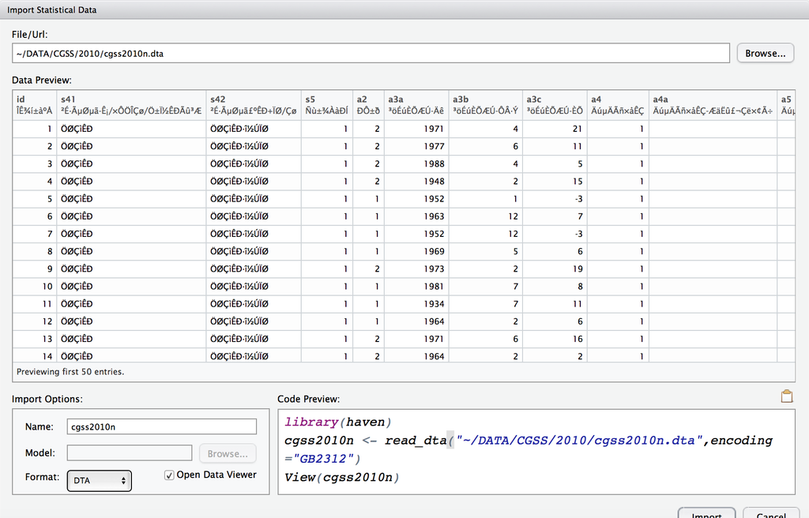

```r
library(haven)
cgss2003 <- read_dta("../data/cgss2003.dta",encoding = "utf-8")
```

## haven读入SPSS数据:CGSS

haven包1.1.1版之前的read_spss默认编码为unicode，无法设定encoding信息。而有时一些中文SPSS数据的编码不是utf-8，导致乱码。可以将数据存为spss低版本再试。1.1.1之后的版本可以设定encoding。

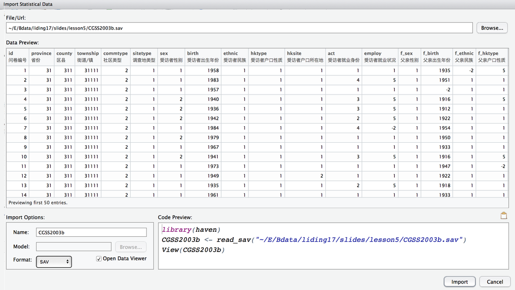

## haven读入SPSS&Stata数据后的标签

变量标签在字段的label属性中；取值标签在labels属性中。

```r
library(haven)
cgss2003 <- read_sav("../data/CGSS2003b.sav")  # spss7.0版数据
str(cgss2003$sitetype)
```

```
## Class 'labelled'  atomic [1:5894] 1 1 1 1 1 1 1 1 1 1 ...
##   ..- attr(*, "label")= chr "调查地类型"
##   ..- attr(*, "format.spss")= chr "F2.0"
##   ..- attr(*, "labels")= Named num [1:7] -3 -2 -1 1 2 3 4
##   .. ..- attr(*, "names")= chr [1:7] "不适合" "无填答/不回答" "不知道/说不清" "直辖市/省会城市的市区" ...
```

```r
attr(cgss2003$sitetype,"label")
```

```
## [1] "调查地类型"
```

```r
attr(cgss2003$sitetype,"labels")
```

```
##                不适合         无填答/不回答         不知道/说不清
##                    -3                    -2                    -1
## 直辖市/省会城市的市区            地级市市区              县城城区
##                     1                     2                     3
##                  集镇
##                     4
```

```r
attr(attr(cgss2003$sitetype,"labels"),"names")[7]
```

```
## [1] "集镇"
```

## 使用label信息：直接统计无标签信息

```r
cgss2003 %>%  count(sitetype)
```

```
## # A tibble: 5 x 2
##   sitetype      n
##   <dbl+lbl> <int>
## 1 -2            1
## 2 1          2325
## 3 2          1527
## 4 3          1299
## 5 4           742
```

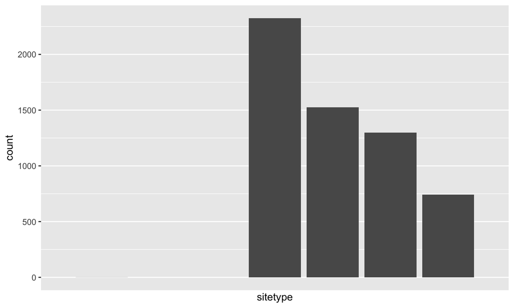

```r
ggplot(cgss2003, aes(x=sitetype)) +
  geom_bar() +
  scale_x_discrete(drop=TRUE)
```

## 使用label信息:使用sjPlot包分析-表

```r
if(!require(sjmisc)) install.packages("sjmisc")
if(!require(sjPlot)) install.packages("sjPlot")
sjt.frq(cgss2003$sitetype)
```

调查地类型

| value | N | raw % | valid % | cumulative % |
| --- | --- | --- | --- | --- |
| 无填答/不回答 | 1 | 0.02 | 0.02 | 0.02 |
| 直辖市/省会城市的市区 | 2325 | 39.45 | 39.45 | 39.46 |
| 地级市市区 | 1527 | 25.91 | 25.91 | 65.37 |
| 县城城区 | 1299 | 22.04 | 22.04 | 87.41 |
| 集镇 | 742 | 12.59 | 12.59 | 100.00 |
| missings | 0 | 0.00 |  |  |
| total N=5894 · valid N=5894 · x̄=2.08 · σ=1.06 |  |  |  |  |

## 使用label信息:使用sjPlot包分析-图

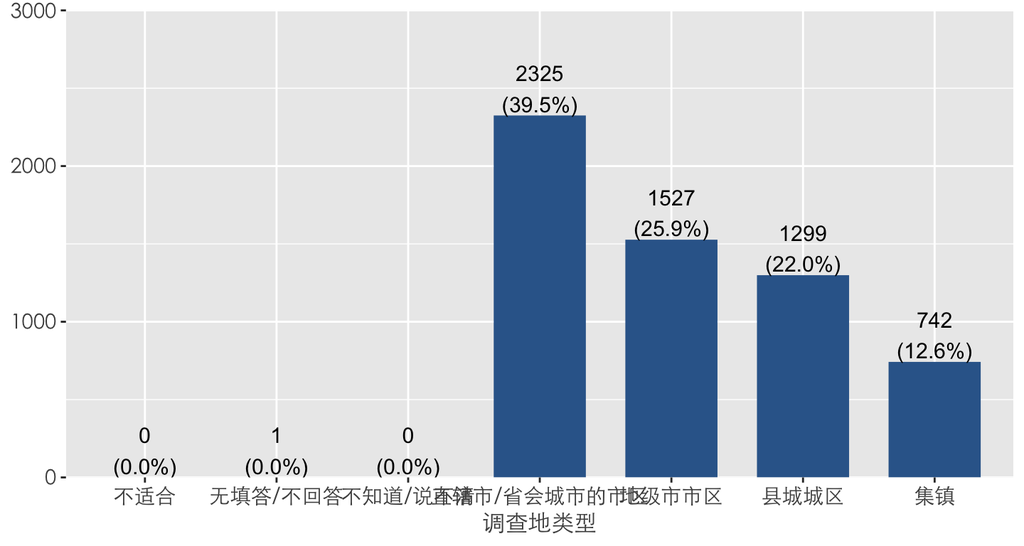

```r
sjPlot::set_theme(theme.font ='STXihei' ) # STHeiti也可
cgss2003  %>% select(sitetype) %>%  sjplot(fun="frq")
```

[更多介绍1](https://strengejacke.wordpress.com/2016/11/14/pipe-friendly-workflow-with-sjplot-sjmisc-and-sjstats-part-1-rstats-tidyverse/);[更多介绍2](https://strengejacke.wordpress.com/sjplot-r-package/);[MAC电脑Rstudio作图中文乱码的解决方案](http://note.youdao.com/noteshare?id=9367dbf7c91458d07f54e256b6c2271d)

## 使用label信息:标签转为因子-更好

使用haven包的as_factor()命令可以将所有labelled的列变成因子。

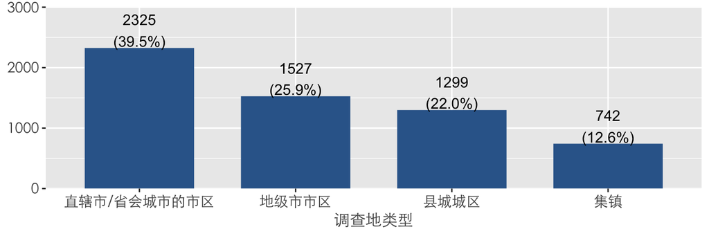

```r
cgss2003  %>%
  filter(sitetype>0) %>%
  select(sitetype) %>%
  haven::as_factor() %>%
  droplevels() %>%
  sjplot(fun="frq",axis.title="调查地类型")
```

## 使用label信息:标签转为因子

用SJ[(strange jack)](http://www.strengejacke.de/sjPlot/)的`sjmisc::to_label()`可以将所有labbled的变量转为因子。

可同时设定将用户缺失值替换为NA(drop.na=TRUE)，删除未用到的取值标签(drop.levels=TRUE)。

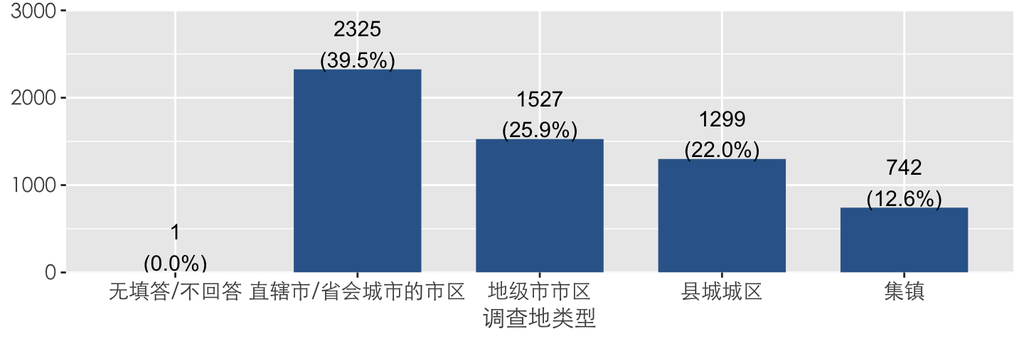

```r
cgss2003  %>%
  select(sitetype) %>%
  sjmisc::to_label(drop.levels=TRUE) %>%
  sjplot(fun="frq",axis.title="调查地类型")
```

## 使用label信息:带标签的连续变量

上面的命令将定义了用户值标签的*连续变量*也变成了因子，不好！最好先处理好这些标签。  
sjlabelled和haven中zap_labels可批量删除标签并将标签对应的取值都替换为NA。

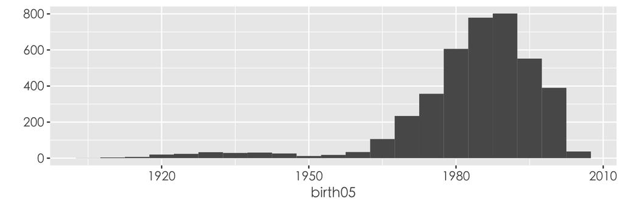

```r
cgss2003  %>%
  select(birth05) %>%
  sjlabelled::zap_labels() %>%
  qplot(x=birth05,data=.,binwidth=5)
```

## **haven**读入SPSS和Stata数据的最优操作

```r
library(haven)
cgss2003 <- read_sav("../data/CGSS2003.sav")
#1、替换特殊缺失值
cgss2003[cgss2003==-1] <- NA;cgss2003[cgss2003==-2] <- NA;cgss2003[cgss2003==-3] <- NA
#2、丢弃没有用到的取值标签（包括上面特殊缺失值标签）
cgss2003 <- sjlabelled::drop_labels(cgss2003)
#3、label转为因子
cgss2003 <- sjmisc::to_label(cgss2003)
# 将剩下的labelled变量转化为数值变量（原来带特殊值标签的连续变量在此）。
w <- which(sapply(cgss2003, class) == 'labelled')
cgss2003[w] <- lapply(cgss2003[w],
                      function(x) as.numeric(as.character(x))
                      )
```

## 分析

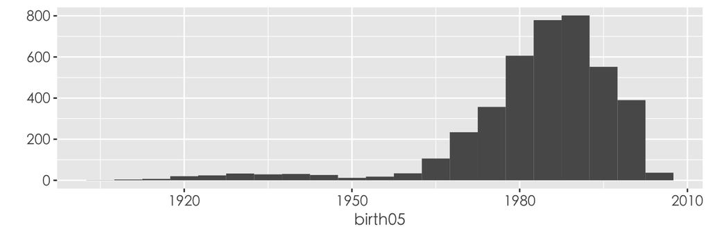

```r
cgss2003  %>%
  qplot(x=birth05,data=.,binwidth=5)
```

## foreign包读入数据

foreign包也是读入数据的常见包。其read.spss可设定reencode等参数。

```r
cgss <- foreign::read.spss("../data/CGSS2003.sav"
                           ,reencode = "GB2312",
                           to.data.frame=TRUE,max.value.labels=50)
```

```
## re-encoding from GB2312
```

```r
table(cgss$sex)
```

```
##
##        不适合 无填答/不回答 不知道/说不清            男            女
##             0             0             0          2835          3059
```

## foreign包读入数据的标签

变量标签存在 variable.labels属性当中；取值标签存在label.table属性中。  
默认将带标签的变量转化为factor类型。部分取值没有label,会自动添加。

```r
attr(cgss, "variable.labels")[1:6]
```

```
##           id     province       county     township     commtype
##   "问卷编号"       "省份"       "区县"    "街道/镇"   "社区类型"
##     sitetype
## "调查地类型"
```

```r
attr(cgss, "label.table")[6]
```

[output not shown]

```r
str(cgss$sitetype)
```

```
##  Factor w/ 7 levels "不适合","无填答/不回答",..: 4 4 4 4 4 4 4 4 4 4 ...
```

## foreign读入数据:删除不必要的因子levels

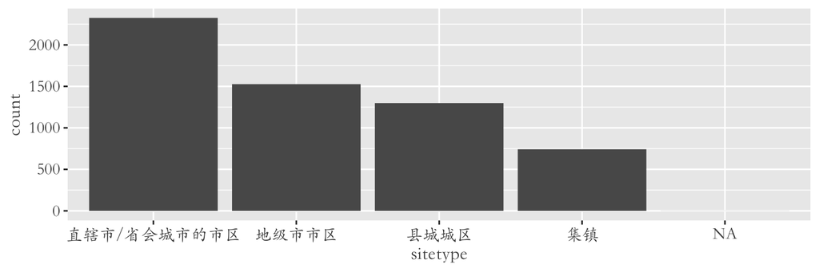

```r
cgss[cgss=="无填答/不回答"] <- NA
cgss[cgss=="不知道/说不清"] <- NA
cgss[cgss=="不适合"] <- NA
cgss[cgss=="不适用"] <- NA
cgss <- droplevels(cgss)
ggplot(data=cgss,aes(x=sitetype))+geom_bar() +theme(text=element_text(family="STKaiti"))
```

```r
#SimSun、SimHei 、STHeiti、 STXihei
```

中文字体名：http://www.cnblogs.com/code/articles/2381967.html

## 针对中文数据的改进

陈华珊自定义的ezdf包针对中文做了一些改进，将变量标签存在了meta数据框中,可分别设变量标签和文本变量的编码。其中定义了简单的汇总函数，可将取值标签自动添加到汇总统计中。

```r
# 安装必要的包，运行一次即可
install.packages('haven', 'data.table')
library(devtools)
install_github('huashan/ezdf')
#install_github('huashan/pander')

# 加载包
library(ezdf)
dat <- readStata("../data/cgss2003.dta",varNameEncoding="GB2312",charEncoding="GBK")
tbl(dat,~ commtype)
```

更多信息:https://github.com/huashan/ezdf/blob/master/Doc/Easy_Data.pdf

## 注意: Strings (characters) 和 factors的差异

- R默认会将字符当做因子变量处理（统计渊源）
- 有时候会带来麻烦
- 使用 `stringsAsFactors = FALSE` 修改默认设定
- 可以将其他数据导出为csv文件(注意编码)然后读入R

## 读入数据库数据

- 电脑首选需要安装ODBC驱动，R需要安装RODBC包
- 然后在电脑系统里设置ODBC数据源(注意字符编码格式)
- 用RDOBC连接数据源，利用SQL语句查询和修改数据

```r
library(RODBC)
setwd("/Users/liding/Documents/空间/data/")
#channel<-odbcConnect("mydsn",uid="user",pwd="rply")
#channel<-odbcConnectAccess("TrainDatabase.mdb") # 不能用
channel <- odbcConnect("train")
sqlTables(channel)
```

```
##    TABLE_CAT TABLE_SCHEM                 TABLE_NAME   TABLE_TYPE REMARKS
## 1       <NA>        <NA>                   MSysACEs SYSTEM TABLE    <NA>
## 2       <NA>        <NA>          MSysAccessStorage SYSTEM TABLE    <NA>
## 3       <NA>        <NA>              MSysAccessXML SYSTEM TABLE    <NA>
## 4       <NA>        <NA> MSysNavPaneGroupCategories SYSTEM TABLE    <NA>
## 5       <NA>        <NA>  MSysNavPaneGroupToObjects SYSTEM TABLE    <NA>
## 6       <NA>        <NA>          MSysNavPaneGroups SYSTEM TABLE    <NA>
## 7       <NA>        <NA>       MSysNavPaneObjectIDs SYSTEM TABLE    <NA>
## 8       <NA>        <NA>                MSysObjects SYSTEM TABLE    <NA>
## 9       <NA>        <NA>            MSysPrimaryKeys SYSTEM TABLE    <NA>
## 10      <NA>        <NA>                MSysQueries SYSTEM TABLE    <NA>
## 11      <NA>        <NA>          MSysRelationships SYSTEM TABLE    <NA>
## 12      <NA>        <NA>                     Pinyin        TABLE    <NA>
## 13      <NA>        <NA>                      Train        TABLE    <NA>
## 14      <NA>        <NA>                  TrainList        TABLE    <NA>
```

```r
df <-sqlFetch(channel, "TrainList")
```

## 数据整理

## Tidy data

1. 每个变量构成一列
2. 每个案例构成一行
3. 每个取值都有自己的单元格
4. 每类观察对象自成一个表

## 比较下面几个数据

下面哪种数据最好用？

```r
table1
```

```
## # A tibble: 6 x 4
##   country      year  cases population
##   <chr>       <int>  <int>      <int>
## 1 Afghanistan  1999    745   19987071
## 2 Afghanistan  2000   2666   20595360
## 3 Brazil       1999  37737  172006362
## 4 Brazil       2000  80488  174504898
## 5 China        1999 212258 1272915272
## 6 China        2000 213766 1280428583
```

```r
table2
```

```
## # A tibble: 12 x 4
##    country      year type            count
##    <chr>       <int> <chr>           <int>
##  1 Afghanistan  1999 cases             745
##  2 Afghanistan  1999 population   19987071
##  3 Afghanistan  2000 cases            2666
##  4 Afghanistan  2000 population   20595360
##  5 Brazil       1999 cases           37737
##  6 Brazil       1999 population  172006362
##  7 Brazil       2000 cases           80488
##  8 Brazil       2000 population  174504898
##  9 China        1999 cases          212258
## 10 China        1999 population 1272915272
## 11 China        2000 cases          213766
## 12 China        2000 population 1280428583
```

## 比较下面几个数据

```r
table3
```

```
## # A tibble: 6 x 3
##   country      year rate
## * <chr>       <int> <chr>
## 1 Afghanistan  1999 745/19987071
## 2 Afghanistan  2000 2666/20595360
## 3 Brazil       1999 37737/172006362
## 4 Brazil       2000 80488/174504898
## 5 China        1999 212258/1272915272
## 6 China        2000 213766/1280428583
```

```r
table4a
```

```
## # A tibble: 3 x 3
##   country     `1999` `2000`
## * <chr>        <int>  <int>
## 1 Afghanistan    745   2666
## 2 Brazil       37737  80488
## 3 China       212258 213766
```

```r
table4b
```

```
## # A tibble: 3 x 3
##   country         `1999`     `2000`
## * <chr>            <int>      <int>
## 1 Afghanistan   19987071   20595360
## 2 Brazil       172006362  174504898
## 3 China       1272915272 1280428583
```

## 使用示例：创建新变量

```r
table1 %>%
  mutate(rate = cases / population * 10000)
```

```
## # A tibble: 6 x 5
##   country      year  cases population  rate
##   <chr>       <int>  <int>      <int> <dbl>
## 1 Afghanistan  1999    745   19987071 0.373
## 2 Afghanistan  2000   2666   20595360 1.29
## 3 Brazil       1999  37737  172006362 2.19
## 4 Brazil       2000  80488  174504898 4.61
## 5 China        1999 212258 1272915272 1.67
## 6 China        2000 213766 1280428583 1.67
```

## 使用示例：汇总

```r
table1 %>%
  count(year, wt = cases)
```

```
## # A tibble: 2 x 2
##    year      n
##   <int>  <int>
## 1  1999 250740
## 2  2000 296920
```

## 使用示例：作图

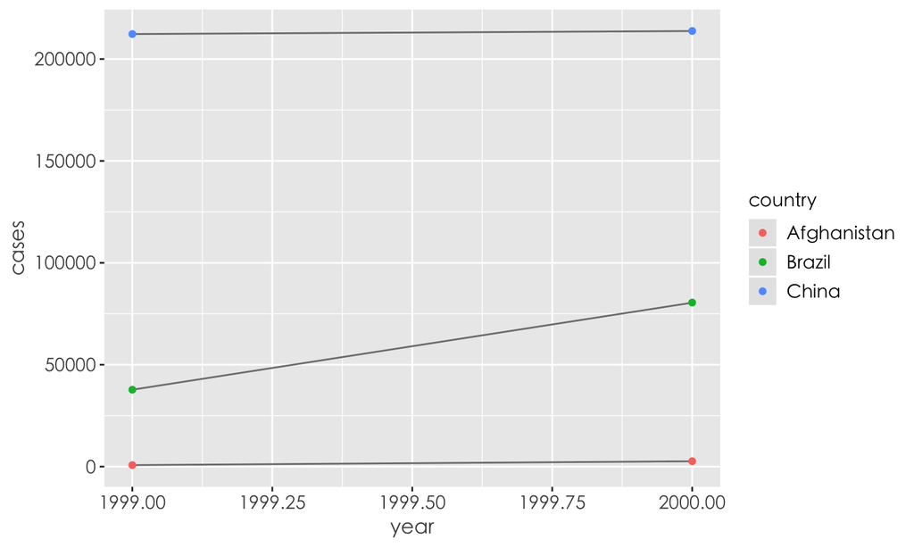

```r
library(ggplot2)
ggplot(table1, aes(year, cases)) +
  geom_line(aes(group = country), colour = "grey50") +
  geom_point(aes(colour = country))
```

## 宽数据变长数据

## 宽数据变长数据

使用`gather`命令

原变量名列表归为新变量key=,取值归入新变量value=

```r
table4a %>%
  gather(`1999`, `2000`, key = "year", value = "cases")
```

```
## # A tibble: 6 x 3
##   country     year   cases
##   <chr>       <chr>  <int>
## 1 Afghanistan 1999     745
## 2 Brazil      1999   37737
## 3 China       1999  212258
## 4 Afghanistan 2000    2666
## 5 Brazil      2000   80488
## 6 China       2000  213766
```

## 宽数据变长数据

```r
table4b %>%
  gather(`1999`, `2000`, key = "year", value = "population")
```

```
## # A tibble: 6 x 3
##   country     year  population
##   <chr>       <chr>      <int>
## 1 Afghanistan 1999    19987071
## 2 Brazil      1999   172006362
## 3 China       1999  1272915272
## 4 Afghanistan 2000    20595360
## 5 Brazil      2000   174504898
## 6 China       2000  1280428583
```

## 长数据变宽数据

```r
table2
```

```
## # A tibble: 12 x 4
##    country      year type            count
##    <chr>       <int> <chr>           <int>
##  1 Afghanistan  1999 cases             745
##  2 Afghanistan  1999 population   19987071
##  3 Afghanistan  2000 cases            2666
##  4 Afghanistan  2000 population   20595360
##  5 Brazil       1999 cases           37737
##  6 Brazil       1999 population  172006362
##  7 Brazil       2000 cases           80488
##  8 Brazil       2000 population  174504898
##  9 China        1999 cases          212258
## 10 China        1999 population 1272915272
## 11 China        2000 cases          213766
## 12 China        2000 population 1280428583
```

## 长数据变宽数据

使用`spread`命令，变量名key来自什么，取值value来自于什么

```r
spread(table2, key = type, value = count)
```

```
## # A tibble: 6 x 4
##   country      year  cases population
##   <chr>       <int>  <int>      <int>
## 1 Afghanistan  1999    745   19987071
## 2 Afghanistan  2000   2666   20595360
## 3 Brazil       1999  37737  172006362
## 4 Brazil       2000  80488  174504898
## 5 China        1999 212258 1272915272
## 6 China        2000 213766 1280428583
```

## 长数据变宽数据

## reshape 命令：Make a Panel Dataset

```r
# Make a Panel Dataset
health <- data.frame(id = rep(1:10, each = 4, len = 40),
                     trial = rep(c(1:4), 10),
                     score = rnorm(40, 3, .75))
health[1:10, ]
```

```
##    id trial    score
## 1   1     1 2.720685
## 2   1     2 2.447872
## 3   1     3 3.333392
## 4   1     4 4.804862
## 5   2     1 1.621637
## 6   2     2 3.074324
## 7   2     3 3.557456
## 8   2     4 2.669672
## 9   3     1 2.113237
## 10  3     2 3.137335
```

## reshape 命令：Long –> Wide

```r
# Reshape : Long --> Wide
health_wide <- reshape(health, v.names = "score", idvar = "id",
                       timevar = "trial", direction = "wide")
health_wide[1:5, ]
```

```
##    id  score.1  score.2  score.3  score.4
## 1   1 2.720685 2.447872 3.333392 4.804862
## 5   2 1.621637 3.074324 3.557456 2.669672
## 9   3 2.113237 3.137335 3.925154 2.976981
## 13  4 1.493258 2.457365 2.336811 2.382131
## 17  5 3.216250 1.648728 4.117747 3.623407
```

```r
head(reshape(health_wide)) # to go back to long format
```

```
##     id trial    score
## 1.1  1     1 2.720685
## 2.1  2     1 1.621637
## 3.1  3     1 2.113237
## 4.1  4     1 1.493258
## 5.1  5     1 3.216250
## 6.1  6     1 2.431946
```

## reshape 命令：Wide –> Long

```r
# Reshape : Wide --> Long
health_long <- reshape(health_wide, idvar = "id", direction = "long")
health_long[1:15, ]
```

```
##      id trial    score
## 1.1   1     1 2.720685
## 2.1   2     1 1.621637
## 3.1   3     1 2.113237
## 4.1   4     1 1.493258
## 5.1   5     1 3.216250
## 6.1   6     1 2.431946
## 7.1   7     1 2.998749
## 8.1   8     1 2.175187
## 9.1   9     1 3.652707
## 10.1 10     1 4.440388
## 1.2   1     2 2.447872
## 2.2   2     2 3.074324
## 3.2   3     2 3.137335
## 4.2   4     2 2.457365
## 5.2   5     2 1.648728
```

## tidy方式：变宽(练习)

```r
spread(health, key = ?, value = ?) # key is the identifier
```

## tidy方式：变长(练习)

```r
# can also reference by column number(2:5)
gather(health_wide, key = ?, value = ?, score.1:score.4)
```

## 其他数据整理命令

数值分裂：`seperate`

数值合并：`unite`

具体参考：http://r4ds.had.co.nz/tidy-data.html#separating-and-uniting

去年期末考试用到了这个命令。请认真研究。

## 数据变形中的缺失值问题

长宽变换得到的数据为齐整的数据，如果原始数据中某些记录或者变量缺乏取值怎么办呢？

- 显性缺失 Explicitly, i.e. flagged with NA.
- 隐性缺失 Implicitly, i.e. simply not present in the data.

具体参考：http://r4ds.had.co.nz/tidy-data.html#missing-values-3

## 数据合并

## 数据合并:创建示例数据

```r
# 创建两个数据
data1 <- data.frame(id = rep(1:5, 3), year = rep(2000:2002, each = 5),
                     group = sample(c("A", "B", "C"), 15, replace = TRUE))

data2 <- data.frame(id = rep(1:5, each = 4), year = rep(2000:2003, 5),
                    score = rnorm(20, 50, 15))
```

```r
head(data1)
```

```
##   id year group
## 1  1 2000     B
## 2  2 2000     B
## 3  3 2000     C
## 4  4 2000     C
## 5  5 2000     A
## 6  1 2001     C
```

```r
head(data2)
```

```
##   id year    score
## 1  1 2000 34.12524
## 2  1 2001 60.58750
## 3  1 2002 46.05366
## 4  1 2003 49.19167
## 5  2 2000 60.17613
## 6  2 2001 57.66083
```

## 数据合并:base包merge命令

```r
# Merge them by id & year, 1:1 merge
data_merge <- merge(data1, data2, by = c("id", "year"))
data_merge
```

```
##    id year group    score
## 1   1 2000     B 34.12524
## 2   1 2001     C 60.58750
## 3   1 2002     A 46.05366
## 4   2 2000     B 60.17613
## 5   2 2001     C 57.66083
## 6   2 2002     A 28.47336
## 7   3 2000     C 52.48359
## 8   3 2001     B 50.39586
## 9   3 2002     A 23.41195
## 10  4 2000     C 59.46818
## 11  4 2001     A 40.33545
## 12  4 2002     C 36.26461
## 13  5 2000     A 47.10721
## 14  5 2001     C 48.90500
## 15  5 2002     A 60.21606
```

## 数据合并:base包merge命令

```r
# 只有一个数据集中有则合并数据集中有.
# left-merge: x.all=TRUE. right-merge:y.all=TRUE
data_merge <- merge(data1, data2, by = c("id", "year"), all = TRUE)
data_merge
```

```
##    id year group    score
## 1   1 2000     B 34.12524
## 2   1 2001     C 60.58750
## 3   1 2002     A 46.05366
## 4   1 2003  <NA> 49.19167
## 5   2 2000     B 60.17613
## 6   2 2001     C 57.66083
## 7   2 2002     A 28.47336
## 8   2 2003  <NA> 45.41270
## 9   3 2000     C 52.48359
## 10  3 2001     B 50.39586
## 11  3 2002     A 23.41195
## 12  3 2003  <NA> 51.03665
## 13  4 2000     C 59.46818
## 14  4 2001     A 40.33545
## 15  4 2002     C 36.26461
## 16  4 2003  <NA> 39.47844
## 17  5 2000     A 47.10721
## 18  5 2001     C 48.90500
## 19  5 2002     A 60.21606
## 20  5 2003  <NA> 49.24918
```

扩展阅读: "http://guides.nyu.edu/quant/merge"

## 两个数据合并:dplyr包命令

```r
inner_merge <- data1 %>% inner_join(data2, by = c("id", "year")) %>% arrange(id)
outer_merge <- data1 %>% full_join(data2, by = c("id", "year")) %>% arrange(id)
```

```r
head(inner_merge)
```

```
##   id year group    score
## 1  1 2000     B 34.12524
## 2  1 2001     C 60.58750
## 3  1 2002     A 46.05366
## 4  2 2000     B 60.17613
## 5  2 2001     C 57.66083
## 6  2 2002     A 28.47336
```

```r
head(outer_merge)
```

```
##   id year group    score
## 1  1 2000     B 34.12524
## 2  1 2001     C 60.58750
## 3  1 2002     A 46.05366
## 4  1 2003  <NA> 49.19167
## 5  2 2000     B 60.17613
## 6  2 2001     C 57.66083
```

## outer join

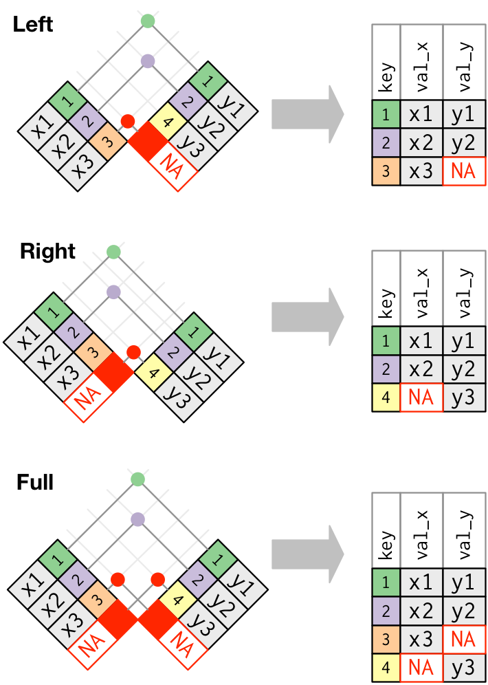

## 两个数据合并:前面的示例数据

```r
tidy4a <- table4a %>%
  gather(`1999`, `2000`, key = "year", value = "cases")
tidy4b <- table4b %>%
  gather(`1999`, `2000`, key = "year", value = "population")
left_join(tidy4a, tidy4b)
```

```
## # A tibble: 6 x 4
##   country     year   cases population
##   <chr>       <chr>  <int>      <int>
## 1 Afghanistan 1999     745   19987071
## 2 Brazil      1999   37737  172006362
## 3 China       1999  212258 1272915272
## 4 Afghanistan 2000    2666   20595360
## 5 Brazil      2000   80488  174504898
## 6 China       2000  213766 1280428583
```

## 数据的合并:基础命令

dataframe的合并

```r
rbind() ## 添加行
cbind() ## 添加列
```